# Multiple Factor Analysis and the MFA Package in R

12/2/2016

## Multiple Factor Analysis in R Using "MFA" Package

- This presentation will give a brief overview of how and when to use Multiple Factor Analysis.
- We will also demonstrate how to do Multiple Factor Analysis using the "MFA" package in R, using a fictitious example.
- The source for this paper is "Multiple factor analysis: principal component analysis for multitable and multiblock data sets" by Herve Abdi, Lynne J. Williams, and Domininique Valentin.

## What is Multiple Factor Analysis, and when should you use it?

- Multiple Factor Analysis (MFA) is used to analyze different sets of data taken on the same observations. These data sets can include different types and numbers of variables.
- The goal is to determine any agreement or disagreement between the data sets. For instance, in the example we walk through in later slides, we see different wine experts rate an assortment of wines on 4 different criteria. Through MFA, we can see how much the experts agree or disagree on each of those criteria.
- One output of MFA is a set of factor scores, which are coordinates that can be used to plot each of the observations. This plot will show how similar the observations are to each other based on their distance from each other on the plot.
- The analysis also produces partial factor scores for each factor, which contain the relative position of the other factors.

## What is MFA? (cont.)

- The main piece of MFA is to conduct a principle component analysis (PCA) on the combined (normalized) data sets. This produces a new set of variables, called components, with each component explaining a portion of the total variance.
- Each of the original variables contributes to each component. The amount a variable contributes to a certain component is called the loading of the variable on that component and is determined through MFA.
- Using the factor scores and loadings, we can determine the contribution of each observation, variable and data table to each component. The observation/variable/table with the highest contribution becomes most important in understanding that component.
- Finally, to compare two tables to one another we can compute the \(R_V\) coefficient and the \(L_g\) coefficient, which reflect the similarity between the two tables.

## Overview of the Steps of MFA

- There are multiple ways to perform MFA on a given data set (i.e. using generalized singular value decomposition, simple singular value decomposition on a transformed data set, cross-product matrices, or using the factor scores from a single data table).
- The "MFA" package in R uses a simple singular value decomposition on a transformed data set, so that is the method we will walk through in this presentation. For others, see the cited paper.

## Overview of the Steps of MFA

- Start with a data set \(\mathbf{X}\) containing \(J\) variables measured on a common \(I\) observations, separated into \(K\) data tables \[ \mathbf{X} = [\mathbf{X_{[1]}} | ... | \mathbf{X_{[K]}}] \]  
  where each matrix \(\mathbf{X_{[i]}}\) has \(I\) rows.

## Normalize the Data

- Center each column by its mean
- Scale each column such that the sum of the squares of its entries is equal to 1

## Calculate the weight of each data table

- Run a simple PCA on each data table
- \(\gamma_i\) is the first singular value for table \(i\)
- The weight for table \(i\) is \[ \alpha_i = \frac{1}{{\gamma_i}^2} \]

## Create the weightings matrix A

- Calculate the weight for each table and store in a matrix, \(\mathbf{A}\) \[ \mathbf{A} = \mbox{diag}\{ \alpha_1\mathbf{1_{[1]}}, \alpha_2\mathbf{1_{[2]}}, ..., \alpha_K\mathbf{1_{[K]}}\} \]  
  where \(\mathbf{1_{[k]}}\) is a vector of ones the length of the number of variables in table \(\mathbf{X_{[k]}}\)

## Transform the original data set using the weightings matrix A

- Scale each data table by the square root of its weight and concatenate into a new, transformed data set \(\mathbf{\tilde{X}}\) \[ \mathbf{\tilde{X}} = [\sqrt{\alpha_1}\mathbf{X_{[1]}} | \sqrt{\alpha_2}\mathbf{X_{[2]}} | ... | \sqrt{\alpha_K}\mathbf{X_{[K]}}] \]

## Simple PCA on Transformed Data

- Singular value decomposition of transformed data gives \[ \mathbf{\tilde{X}} = \mathbf{\tilde{U}}\mathbf{\tilde{\Delta}}\mathbf{\tilde{V}}^T \]
- From this, we can calculate the factor scores as well as the loadings.

## Calculating the Factor Scores and Loadings

- Factor Scores \[ \mathbf{F} = \mathbf{\tilde{U}}\mathbf{\tilde{\Delta}} \]
- Loadings \[ \mathbf{Q} = \mathbf{\tilde{V}}\mathbf{A}^{-1/2} \] where \(\mathbf{A}\) is the matrix of the weights.

## Calculating the Partial Factor Scores

- First obtain partial loadings for factor \(i\), \(\mathbf{Q_{[i]}}\), using the loadings table \(\mathbf{Q}\) \[ \mathbf{Q} = [\mathbf{Q_{[1]}}^T | ... | \mathbf{Q_{[K]}}^T]^T \]
- Partial factor scores for factor \(i\) \[ \mathbf{F_{[i]}} = K * \alpha_i * \mathbf{X_{[i]}}\mathbf{Q_{[i]}} \] where \(K\) is the total number of factors in the analysis, \(\mathbf{X_{[i]}}\) is the original data table, and \(\mathbf{Q_{[i]}}\) is the matrix of partial loadings for that factor

## Functions in the "MFA" Package

- `mfa(data, sets, ncomps = NULL, center = TRUE, scale = TRUE)`
- `eigensummary(mfa_object)`
- `bootstrap(mfa_object, number of samples)`
- `contrib_var(mfa_object, sets, tables)`
- `contrib_obs(mfa_object)`
- `contrib_table(mfa_object, sets, tables)`
- `RV(table1,table2)`
- `RV_table(dataset, sets)`
- `Lg(table1, table2)`
- `Lg_table(dataset,sets)`
- `plot(mfa_object, type)`

## The `mfa` function

```r
mymfa <- mfa(data, sets, ncomps = NULL, center = TRUE, scale = TRUE)
```

Creates object of class "mfa" containing

1. eigenvalues for the original data set
2. common factor scores
3. partial factor scores
4. loadings matrix

## Inputs to the `mfa` function

- "data": data frame or a matrix
- "sets": list of vectors of length equal to the number of data tables. Each vector contains variables from the original data in that table. The vectors can either be numeric (column indices) or characters (column names)
- "ncomps": an integer or NULL value, specifying the number of components you want in the output of the MFA
- "center": either a logical value or a vector of length equal to the total number of active variables, specifying the value around which each column will be centered. If "center" is TRUE, each column will be centered around its mean. If "center" is FALSE, no centering will be done.
- "scale": either a logical value or a vector of length equal to the total number of active variables, specifying the value by which each column will be scaled. If "scale" is TRUE, each column is scaled by its standard deviation. If "scale" is FALSE, no scaling will be done.

## Example of how to use the "MFA" Package on the wines dataset

- The data contains the evaluation of 12 different wines by 10 expert assessors. Each assessor measured the wine on 4 criteria–cat-pee, passionfruit, green pepper and mineral–as well as any other criteria they desired. The first 10 columns of the raw data look like this:

```
##     ID V1 V2 V3 V4 V5 V6 V1.1 V2.1 V3.1
## 1  NZ1  8  6  7  4  1  6    8    6    8
## 2  NZ2  7  5  8  1  2  8    6    5    6
## 3  NZ3  6  5  6  5  3  4    6    6    6
## 4  NZ4  9  6  8  4  3  5    8    6    8
## 5  FR1  2  2  2  8  7  3    2    3    1
## 6  FR2  3  4  4  9  6  1    4    3    4
## 7  FR3  5  3  5  4  8  3    3    3    2
## 8  FR4  5  2  4  8  7  4    4    3    5
## 9  CA1  8  6  8  4  4  7    8    6    9
## 10 CA2  4  6  2  5  3  4    5    5    5
## 11 CA3  8  4  8  1  3  3    8    4    8
## 12 CA4  5  3  6  4  4  2    5    3    7
```

## Performing MFA on the data set "wines"

- Printing the object "mymfa" gives a summary of the output from the analysis

```r
mymfa <- mfa(wines, sets, ncomps = 2, center = TRUE, scale = scaling_vec)
mymfa
```

```
## object of class "mfa"
## number of observations: 12
## number of active variables: 53
## number of data tables: 10
## number of components called: 2
## Eigenvalues (max of 2): 0.77 0.123
## Loadings (dimension 1): -0.294 -0.267 -0.26 0.241 0.286 -0.233 -0.297 -0.296 -0.267 0.256 -0.238 -0.222 -0.305 -0.136 -0.258 0.203 -0.277 0.267 -0.313 -0.261 -0.303 0.23 -0.205 -0.296 -0.213 -0.268 0.124 -0.259 0.177 -0.302 -0.277 -0.265 0.231 -0.205 -0.275 -0.246 -0.277 0.18 -0.276 -0.247 -0.235…
```

- Other elements of the object "mymfa" can be called in the following way:

```r
mymfa$eigen_values
mymfa$common_factor_scores
mymfa$partial_factor_scores
mymfa$loadings
```

## Summarize eigenvalues

- The function `eigensummary` in the "MFA" package allows you to create a simple table containing the eigenvalue, singular value, and percent inertia for each component.

```r
mymfa2 <- mfa(wines, sets, ncomps = NULL, center = TRUE, scale = scaling_vec)
eigensummary(mymfa2)
```

```
##                        X1     X2     X3     X4     X5     X6     X7     X8
## Singular_value      0.878  0.351  0.301  0.276  0.244  0.198  0.176  0.158
## Eigenvalue          0.770  0.123  0.091  0.076  0.060  0.039  0.031  0.025
## Cumulative          0.770  0.893  0.984  1.060  1.120  1.159  1.190  1.215
## Percent_Inertia    61.000 10.000  7.000  6.000  5.000  3.000  2.000  2.000
## Cumulative_inertia 61.000 71.000 78.000 84.000 89.000 92.000 94.000 96.000
##                        X9    X10     X11     X12
## Singular_value      0.137  0.116   0.106   0.000
## Eigenvalue          0.019  0.013   0.011   0.000
## Cumulative          1.234  1.247   1.258   1.258
## Percent_Inertia     2.000  1.000   1.000   0.000
## Cumulative_inertia 98.000 99.000 100.000 100.000
```

## Plotting method

We can use the plot method of an mfa object to visualize the compromise of tables, partial factor scores, and variable loadings for any given two dimensions/ There are five different types of plots this method could create

- Type 1: plot for factor scores
- Type 2: a bipot of partial factor scores and partial loadings for any specific accessor
- Type 3: all 10 biplots
- Type 4: a plot of partial factor scores for any specific accessor
- Type 5: a plot of variale loadings for each accessor

## Plotting method examples

- to call a specific type of plot, see below examples:

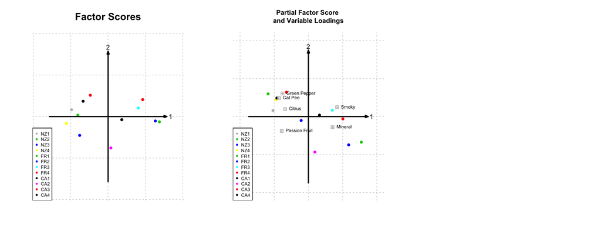

```r
par(mfrow=c(1,3))
plot(mymfa, type = 1)
plot(mymfa, type = 2, X = 1, loading_labels =
       c("Cat Pee", "Passion Fruit", "Green Pepper", "Mineral", "Smoky", "Citrus"))
```

```r
plot(mymfa, type = 3, loading_labels = NULL)
plot(mymfa, type = 4, X = 1)
plot(mymfa, type = 5, X = 1)
```

[output not shown]

## Contributions of an Observation to a Dimension

```r
contrib_obs(mymfa)
# mymfa is an object of class 'MFA'
```

\[ ctr_{i,l} = \frac{(m_{i}\times f_{i,l}^2)}{\lambda_{l}}\]

- i, observation index
- l, dimension index
- \(m_{i}\), mass of the i-th observation
- \(f_{i,l}\), factor score of the i-th observation for the l-th dimension
- \(\lambda_{l}\), eigenvalue of dimension l

## Contributions of a Variable to a Dimension

```r
contrib_var(mymfa, sets, tables)
# sets is the list of the variables we will study
# tables are the original tables
```

\[ ctr_{j,l} = a_{j}\times q_{j,l}^2\]

- j, variable index
- l, dimension index
- \(a_{j}\), weight for the j-th variable
- \(q_{j,l}\), loading of the j-th variable for the l-th dimension

## Contributions of a Table to a Dimension

```r
contrib_tables(mymfa, sets, tables)
```

\[ ctr_{k,l} = \sum_{j=1}^{J_{k}} ctr_{j,l}\]

- k, table index
- l, dimension index
- Sum is over the variables of table k
- \(ctr_{j,l}\), the contribution of variable j to dimension l

## Between-Table Structure

```r
RV(table1, table2)
RV_table(dataset, setsarg = list(1:2, 3:4))
# dataset is a dataframe with numeric variables
# setsarg is list of indices defining subsets
```

\[\scriptsize{RV_{k,k'} = \frac{ Tr((X_{[k]}.X_{[k]}^{T})\times (X_{[k']}.X_{[k']}^{T}))} {\sqrt{(Tr((X_{[k]}.X_{[k]}^{T})\times (X_{[k]}.X_{[k]}^{T})) \times Tr((X_{[k]}.X_{[k]}^{T})\times (X_{[k]}.X_{[k]}^{T})))}}}\]

- \(X_{[k]}\), first table of data
- \(X_{[k']}\), second table of data
- Tr, trace operation

## Lg Coefficient

The LG coefficient between two tables is defined as:

\[ L_{g(k,k')} = Tr[(X_kX_k^T) \times (X_{k'} X_{k'}^T)] \times (\alpha_k \times \alpha_{k'}) \]

where \(\alpha_k\) is the inverse of the largest singular value squared of \(X_k\).

The function `Lg` computes the Lg coefficient between two tables. It takes as inputs two tables or matrices, and outputs a scalar.

```r
library(MFA)
Lgtable1_table2 <- Lg(tables[[1]], tables[[2]])
Lgtable1_table2
```

```
## [1] 0.9180402
```

## Lg_table

The function `Lg_table` computes the matrix of Lg coefficients for various tables. It takes as inputs a dataset, and a list of indices indicating which tables from the dataset to compute the Lg coefficients for.

```r
sets_shift2 <- list(1:6,7:12,13:18,24:29,39:44)
dataset2 <- as.data.frame(tables)
Lg_dataset <- Lg_table(dataset2, sets_shift2)
Lg_dataset
```

```
##           [,1]      [,2]      [,3]      [,4]      [,5]
## [1,] 1.0585802 0.9180402 0.9443864 0.9026253 0.8372226
## [2,] 0.9180402 1.0573275 0.8507391 0.8004526 0.9112028
## [3,] 0.9443864 0.8507391 1.1381478 1.0152083 0.8301982
## [4,] 0.9026253 0.8004526 1.0152083 1.1991973 0.8711050
## [5,] 0.8372226 0.9112028 0.8301982 0.8711050 1.1469494
```

## Bootstrap Procedure

Bootstrap for the factor scores is for estimating the stability of the compromise factor scores.

First, we sample from the table index. If the dataset is combined with k tables, we sample from 1 to k for k times, which becomes our first sample set. Second, we compute the partial factor scores for our sample sets, and we denote it as \[F_1,\dots,F_k\] and denote \[F_1^*=\frac{1}{k}\sum_{i=1}^k F_i\] as the bootstrapped estimate of the factor scores from the first sample.

## Bootstrap Procedure Continued

Repeat step 1 and 2 for large number of times (e.g., L=1000), so we can get \[F_1^*,F_2^*,\dots,F_L^*\]

Then we can calculate the mean and variance of bootstrap samples: \[\bar{F}^*= \frac{1}{L}\sum_{l=1}^L F_l^*\] \[\hat{\sigma}_{F^*}^2=\frac{1}{L}(\sum_{l=1}^{L}( F_l^*-\bar{F}^*)\cdot(F_l^*-\bar{F}^*))\]

Finally, we can get the bootstrap ratio by \(\frac{\bar{F}^*}{\hat{\sigma}_{F^*}}\). The bootstrap ratio gives information of which observations most reliably contribute to a component.

## Bootstrap Method in the MFA Package

The bootstrap is a method for mfa objects

usage: bootstrap(mfa,value)

inputs: a mfa object and the number of times of bootstrap

outputs: a list, containing the mean, standard deviation and bootstrap ratio; Also, it creates plot of bootstrap ratio for each dimension.

## Example of Bootstrap

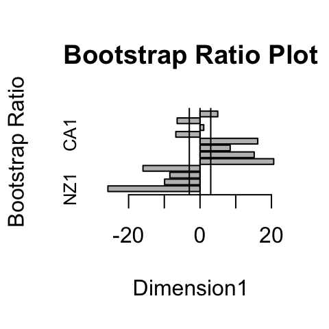

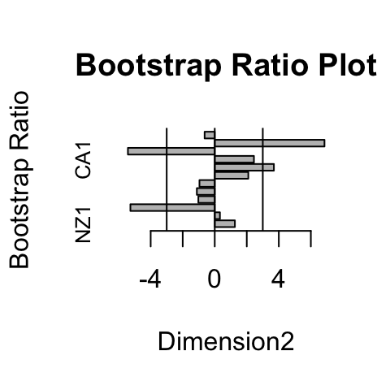

```
## $mean
##           [,1]        [,2]
## 1  -0.97992983  0.16358615
## 2  -0.81229838  0.03427282
## 3  -0.76044883 -0.45506473
## 4  -1.11340506 -0.16219519
## 5   1.37234267 -0.13301089
## 6   1.26522285 -0.10955786
## 7   0.80632810  0.20674236
## 8   0.92573602  0.40654407
## 9  -0.67219375  0.37161159
## 10  0.07477514 -0.75885962
## 11 -0.47445522  0.51418546
## 12  0.36832630 -0.07825416
##
```

[output cut: 29 more lines]

## Shiny app for the wine data

We have published a shiny app to exemplify various graphical features of the MFA package for the wines dataset. To use it, simply go to the url: https://xzhang.shinyapps.io/Shiny_MFA/

On the app, one can select from one of six different plots. They include:

1. a plot of common factor scores,
2. a bipot of partial factor scores and partial loadings for each accessor,
3. all 10 biplots,
4. a plot of partial factor scores for each accessor,
5. a plot of variale loadings for each accessor, and
6. a barplot of eigenvalues.

For plots 2), 4), and 5), there is a slider input to select the accessor ID.

For plot 6), there is a slider input to indicate the number of components to keep.

There is also a slider input to alter the size of the text and points.

## Shiny app for the wine data: example

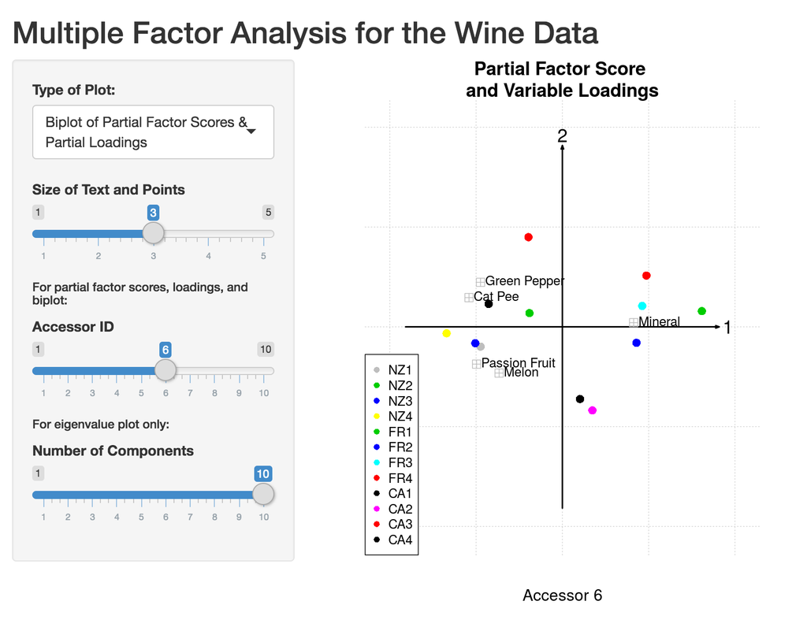